# ISLR Chapter 6 Labs

This is an R Notebook containing the chapter 6 labs from ‘An Introduction to Statistical Learning with Applications in R’

## Hitters Data Details

Major League Baseball Data from the 1986 and 1987 seasons. A data frame with 322 observations of major league players.

Variables:

- AtBat: Number of times at bat in 1986
- Hits: Number of hits in 1986
- HmRun: Number of home runs in 1986
- Runs: Number of runs in 1986
- RBI: Number of runs batted in in 1986
- Walks: Number of walks in 1986
- Years: Number of years in the major leagues
- CAtBat: Number of times at bat during his career
- CHits: Number of hits during his career
- CHmRun: Number of home runs during his career
- CRuns: Number of runs during his career
- CRBI: Number of runs batted in during his career
- CWalks: Number of walks during his career
- League: A factor with levels A and N indicating player’s league at the end of 1986
- Division: A factor with levels E and W indicating player’s division at the end of 1986
- PutOuts: Number of put outs in 1986
- Assists: Number of assists in 1986
- Errors: Number of errors in 1986
- Salary: 1987 annual salary on opening day in thousands of dollars
- NewLeague: A factor with levels A and N indicating player’s league at the beginning of 1987

## Best Subset Selection

Perform subset selection with 19 variables

R squared values:

```
 [1] 0.3214501 0.4252237 0.4514294 0.4754067 0.4908036 0.5087146 0.5141227 0.5285569
 [9] 0.5346124 0.5404950 0.5426153 0.5436302 0.5444570 0.5452164 0.5454692 0.5457656
[17] 0.5459518 0.5460945 0.5461159
```

As expected, the R2 statistic increases monotonically as more variables are included.

Largest Adjusted Rsqr:

```
[1] 11
```

Smallest Cp:

```
[1] 10
```

Smallest BIC:

```
[1] 6
```

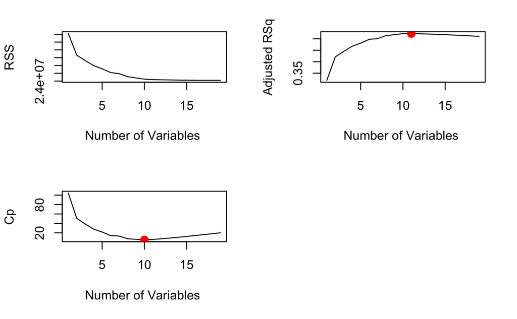

### Plot the selected variables for the best model (r2)

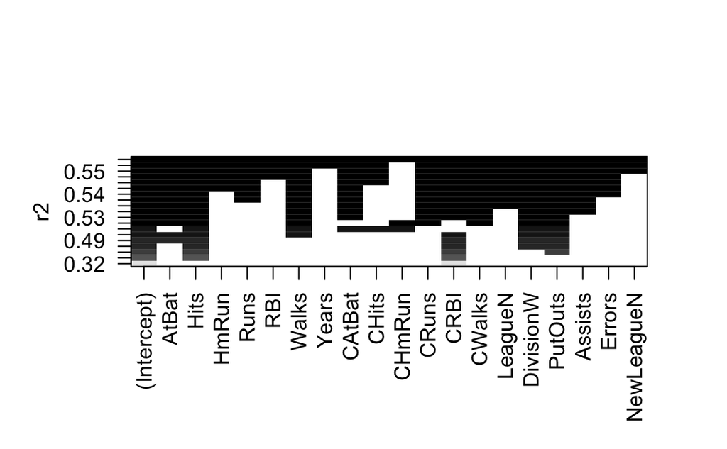

### Plot the selected variables for the best model (adjr2)

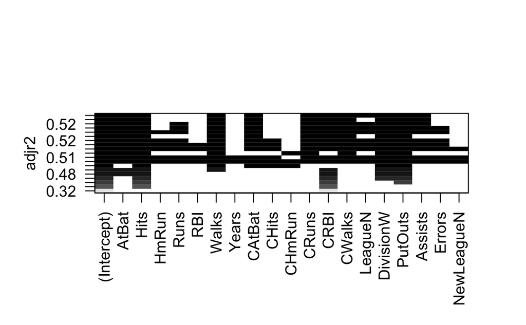

### Plot the selected variables for the best model (Cp)

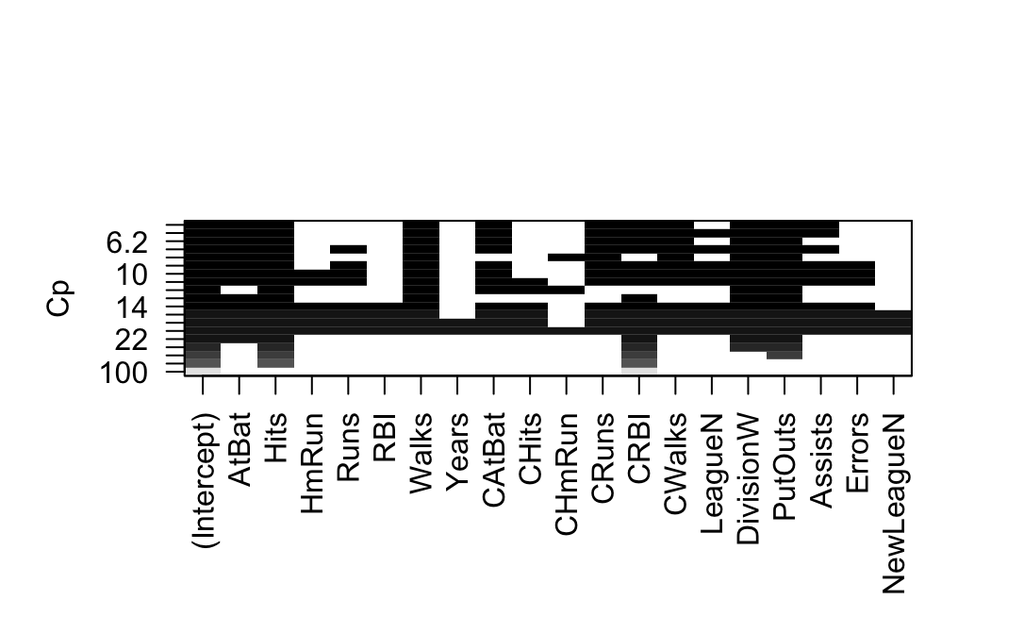

### Plot the selected variables for the best model (bic)

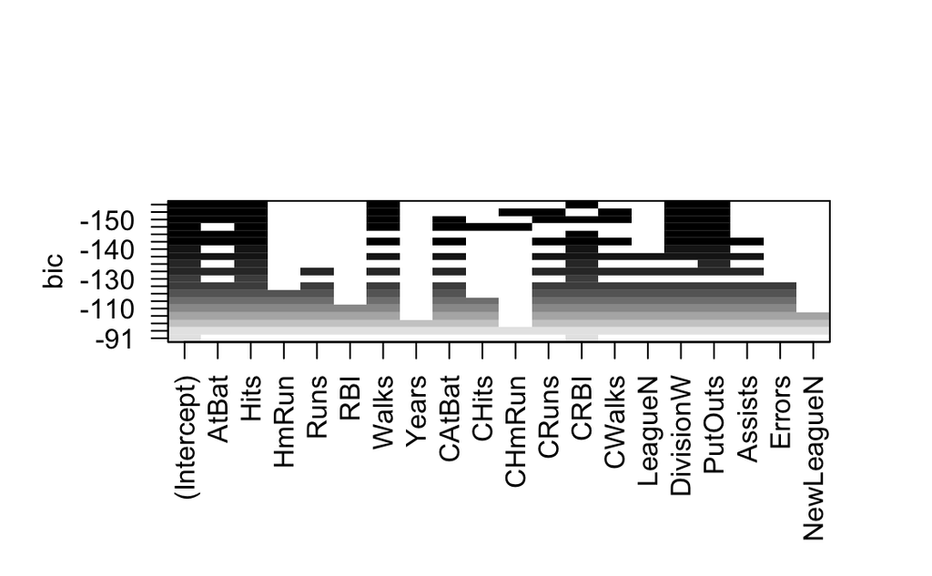

## Lab 6.5.3: Choosing Among Models Using the Validation Set Approach and Cross-Validation

The MSE Values for subsets 1-19 are:

```
 [1] 164377.3 144405.5 152175.7 145198.4 137902.1 139175.7 126849.0 136191.4 132889.6
[10] 135434.9 136963.3 140694.9 140690.9 141951.2 141508.2 142164.4 141767.4 142339.6
[19] 142238.2
```

```
 (Intercept)        AtBat         Hits        HmRun        Walks       CAtBat        CRuns
  71.8074075   -1.5038124    5.9130470  -11.5241809    8.4349759   -0.1654850    1.7064330
        CRBI       CWalks    DivisionW      PutOuts
   0.7903694   -0.9107515 -109.5616997    0.2426078
```

```
 (Intercept)        AtBat         Hits        Walks       CAtBat        CRuns         CRBI
 162.5354420   -2.1686501    6.9180175    5.7732246   -0.1300798    1.4082490    0.7743122
      CWalks    DivisionW      PutOuts      Assists
  -0.8308264 -112.3800575    0.2973726    0.2831680
```

We now perform cross-validation…

This has given us a 10×19 matrix, of which the (i, j)th element corresponds to the test MSE for the ith cross-validation fold for the best j-variable model.

Obtain the average over the columns of the above matrix in order to obtain a vector for which the jth element is the cross- validation error for the j-variable model.

```
       1        2        3        4        5        6        7        8        9       10
149821.1 130922.0 139127.0 131028.8 131050.2 119538.6 124286.1 113580.0 115556.5 112216.7
      11       12       13       14       15       16       17       18       19
113251.2 115755.9 117820.8 119481.2 120121.6 120074.3 120084.8 120085.8 120403.5
```

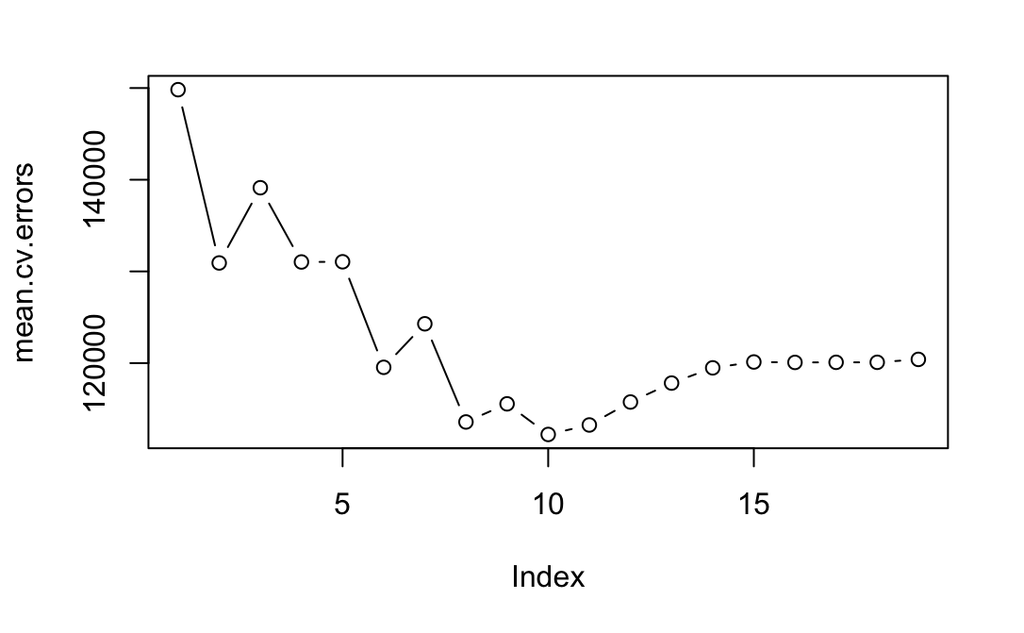

```
 (Intercept)        AtBat         Hits        Walks       CAtBat        CRuns         CRBI
 135.7512195   -2.1277482    6.9236994    5.6202755   -0.1389914    1.4553310    0.7852528
      CWalks      LeagueN    DivisionW      PutOuts      Assists
  -0.8228559   43.1116152 -111.1460252    0.2894087    0.2688277
```

## Lab 6.6.1: Ridge Regression

The current setup has 20 rows (one for each predictor plus an intercept) and 100 columns for the lamda values:

```
[1]  20 100
```

Experiment with lamda values to see as lamda increases the l2 norm of the coefficients decrease (lambda, coefficients then l2 norm)

```
[1] 705.4802
 (Intercept)        AtBat         Hits        HmRun         Runs          RBI        Walks
 54.32519950   0.11211115   0.65622409   1.17980910   0.93769713   0.84718546   1.31987948
       Years       CAtBat        CHits       CHmRun        CRuns         CRBI       CWalks
  2.59640425   0.01083413   0.04674557   0.33777318   0.09355528   0.09780402   0.07189612
     LeagueN    DivisionW      PutOuts      Assists       Errors   NewLeagueN
 13.68370191 -54.65877750   0.11852289   0.01606037  -0.70358655   8.61181213
[1] 57.11001
[1] 11497.57
  (Intercept)         AtBat          Hits         HmRun          Runs           RBI         Walks
407.356050200   0.036957182   0.138180344   0.524629976   0.230701523   0.239841459   0.289618741
        Years        CAtBat         CHits        CHmRun         CRuns          CRBI        CWalks
  1.107702929   0.003131815   0.011653637   0.087545670   0.023379882   0.024138320   0.025015421
      LeagueN     DivisionW       PutOuts       Assists        Errors    NewLeagueN
  0.085028114  -6.215440973   0.016482577   0.002612988  -0.020502690   0.301433531
[1] 6.360612
```

We can use the predict() function for numerous purposes such as predicting ridge coefficients for a new value of lambda, for example 50:

```
  (Intercept)         AtBat          Hits         HmRun          Runs           RBI         Walks
 4.876610e+01 -3.580999e-01  1.969359e+00 -1.278248e+00  1.145892e+00  8.038292e-01  2.716186e+00
        Years        CAtBat         CHits        CHmRun         CRuns          CRBI        CWalks
-6.218319e+00  5.447837e-03  1.064895e-01  6.244860e-01  2.214985e-01  2.186914e-01 -1.500245e-01
      LeagueN     DivisionW       PutOuts       Assists        Errors    NewLeagueN
 4.592589e+01 -1.182011e+02  2.502322e-01  1.215665e-01 -3.278600e+00 -9.496680e+00
```

Now we fit the ridge regression model on the training set, and evaluate its MSE on the test set, using lambda = 4:

```
[1] 142199.2
```

Note that if we had instead simply fit a model with just an intercept, we would have predicted each test observation using the mean of the training observations. In that case, we could compute the test set MSE like this:

```r
mean((mean(y[train])-y.test)^2)
```

```
[1] 224669.9
```

We could also get the same result by fitting a ridge regression model with a very large value of lambda for instance s=1e10:

```r
ridge.mod=glmnet(x[train,],y[train],alpha=0,lambda=grid, thresh=1e-12)
ridge.pred=predict(ridge.mod,s=1e10,newx=x[test,])
mean((ridge.pred-y.test)^2)
```

```
[1] 224669.8
```

The lambda that results in the smallest cross validation error is:

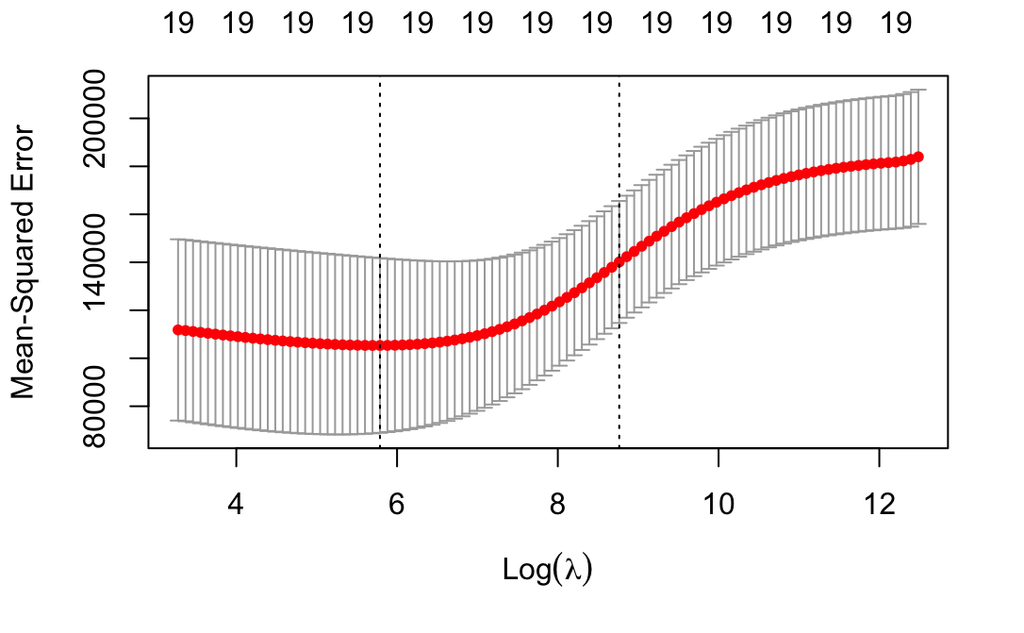

```
[1] 326.0828
```

The MSE associated with this value of Lambda is:

```
[1] 139856.6
```

Refit the ridge regression model on the full data set, using the value of lambda chosen by cross-validation:

```
 (Intercept)        AtBat         Hits        HmRun         Runs
 15.44383135   0.07715547   0.85911581   0.60103107   1.06369007
         RBI        Walks        Years       CAtBat        CHits
  0.87936105   1.62444616   1.35254780   0.01134999   0.05746654
      CHmRun        CRuns         CRBI       CWalks      LeagueN
  0.40680157   0.11456224   0.12116504   0.05299202  22.09143189
   DivisionW      PutOuts      Assists       Errors   NewLeagueN
-79.04032637   0.16619903   0.02941950  -1.36092945   9.12487767
```

As expected none of the coefficients are 0 which means ridge regression does not perform variable selection.

## Lab 6.2.2: The Lasso

### Coefficient plot for Lasso

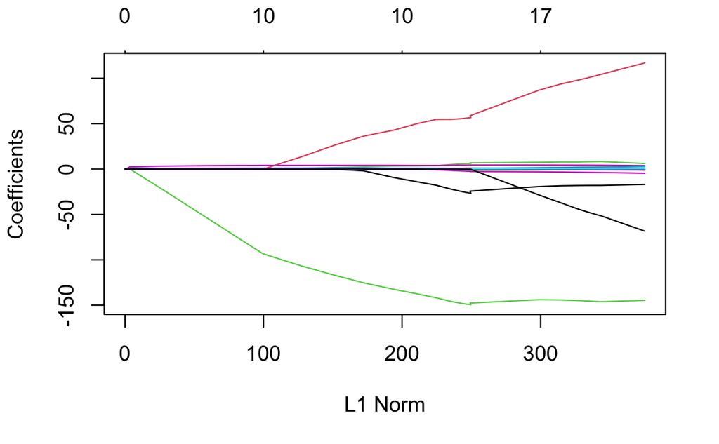

We can see from the coefficient plot that depending on the choice of tuning parameter, some of the coefficients will be exactly equal to zero. We now perform cross-validation and compute the associated test error, which is:

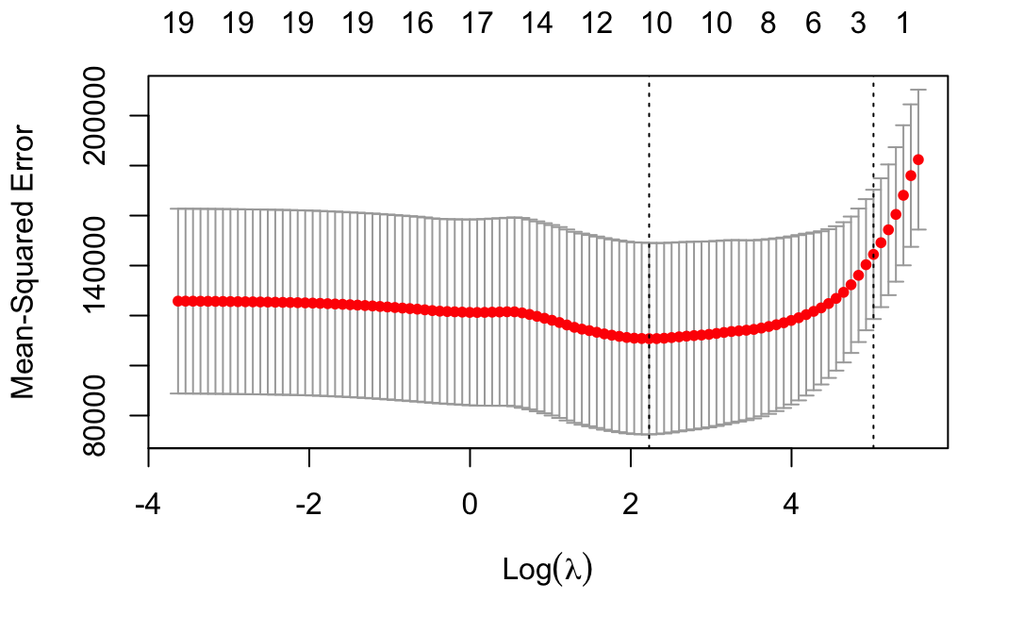

```
[1] 143673.6
```

```
  (Intercept)         AtBat          Hits         HmRun          Runs
   1.27479059   -0.05497143    2.18034583    0.00000000    0.00000000
          RBI         Walks         Years        CAtBat         CHits
   0.00000000    2.29192406   -0.33806109    0.00000000    0.00000000
       CHmRun         CRuns          CRBI        CWalks       LeagueN
   0.02825013    0.21628385    0.41712537    0.00000000   20.28615023
    DivisionW       PutOuts       Assists        Errors    NewLeagueN
-116.16755870    0.23752385    0.00000000   -0.85629148    0.00000000
```

So the lasso model with lasso chosen by cross-validation contains only 11 variables.

```
  (Intercept)         AtBat          Hits         Walks         Years
   1.27479059   -0.05497143    2.18034583    2.29192406   -0.33806109
       CHmRun         CRuns          CRBI       LeagueN     DivisionW
   0.02825013    0.21628385    0.41712537   20.28615023 -116.16755870
      PutOuts        Errors
   0.23752385   -0.85629148
```